# Análise de Componentes Principais (ACP)

09 December 2025

# Exercício 1 — NCI60 (expressão génica; p ≈ 6.830)

**Dados**: `ISLR2::NCI60` (64 linhas = linhas celulares; ~6.830 genes como variáveis).

1. Use a library `ISLR2` e obtenha a matriz `NCI60$data`. Quantas variáveis (genes) existem? Há valores em falta?
2. Construa `X <- scale(NCI60$data)` (centrar e padronizar por coluna). Justifique a escolha de **correlações** em vez de **covariâncias** neste contexto.
3. Aplique `prcomp` a `X` (não volte a padronizar dentro de `prcomp`). Extraia **valores próprios**, **PVE** e **PVE acumulada**. Faça o **scree plot** e o gráfico da PVE acumulada.
4. Faça um gráfico **CP1 vs CP2** dos *scores*. Use `NCI60$labs` apenas para **colorir** os pontos por tipo de cancro (não entra na ACP). Comente padrões/separações.
5. Identifique os **25 genes** com maiores |loadings| em **CP1** e em **CP2** (duas listas). Discuta se há sobreposição entre as listas.

```r
library(ISLR2)
library(tidyverse)
library(broom)
library(palmerpenguins)
library(nycflights13)
library(car)           # VIF e diagnóstico
library(performance)   # checks de suposições
library(GGally)        # ggpairs
library(see)

nci <- ISLR2::NCI60

X <- scale(nci$data)


cova <- cov(X)

corr <- prcomp(X,center = TRUE,scale=FALSE)
glimpse(corr)
```

```
## List of 5
##  $ sdev    : num [1:64] 27.9 21.5 19.8 17 16 ...
##  $ rotation: num [1:6830, 1:64] -0.01068 -0.00231 -0.00588 0.00328 -0.00768 ...
##   ..- attr(*, "dimnames")=List of 2
##   .. ..$ : chr [1:6830] "1" "2" "3" "4" ...
##   .. ..$ : chr [1:64] "PC1" "PC2" "PC3" "PC4" ...
##  $ center  : Named num [1:6830] 1.91e-17 4.16e-17 -8.33e-17 -7.11e-17 1.04e-17 ...
##   ..- attr(*, "names")= chr [1:6830] "1" "2" "3" "4" ...
##  $ scale   : Named num [1:6830] 0.441 0.757 0.433 1.092 0.485 ...
##   ..- attr(*, "names")= chr [1:6830] "1" "2" "3" "4" ...
##  $ x       : num [1:64, 1:64] -19.7 -22.9 -27.2 -42.5 -55 ...
##   ..- attr(*, "dimnames")=List of 2
##   .. ..$ : chr [1:64] "V1" "V2" "V3" "V4" ...
##   .. ..$ : chr [1:64] "PC1" "PC2" "PC3" "PC4" ...
##  - attr(*, "class")= chr "prcomp"
```

```r
summary(corr)
```

```
## Importance of components:
##                            PC1      PC2      PC3      PC4      PC5      PC6
## Standard deviation     27.8535 21.48136 19.82046 17.03256 15.97181 15.72108
## Proportion of Variance  0.1136  0.06756  0.05752  0.04248  0.03735  0.03619
## Cumulative Proportion   0.1136  0.18115  0.23867  0.28115  0.31850  0.35468
##                             PC7      PC8      PC9     PC10     PC11     PC12
## Standard deviation     14.47145 13.54427 13.14400 12.73860 12.68672 12.15769
## Proportion of Variance  0.03066  0.02686  0.02529  0.02376  0.02357  0.02164
## Cumulative Proportion   0.38534  0.41220  0.43750  0.46126  0.48482  0.50646
##                            PC13     PC14     PC15     PC16     PC17     PC18
## Standard deviation     11.83019 11.62554 11.43779 11.00051 10.65666 10.48880
## Proportion of Variance  0.02049  0.01979  0.01915  0.01772  0.01663  0.01611
## Cumulative Proportion   0.52695  0.54674  0.56590  0.58361  0.60024  0.61635
##                            PC19    PC20     PC21    PC22    PC23    PC24
## Standard deviation     10.43518 10.3219 10.14608 10.0544 9.90265 9.64766
## Proportion of Variance  0.01594  0.0156  0.01507  0.0148 0.01436 0.01363
## Cumulative Proportion   0.63229  0.6479  0.66296  0.6778 0.69212 0.70575
##                           PC25    PC26    PC27   PC28    PC29    PC30    PC31
## Standard deviation     9.50764 9.33253 9.27320 9.0900 8.98117 8.75003 8.59962
## Proportion of Variance 0.01324 0.01275 0.01259 0.0121 0.01181 0.01121 0.01083
## Cumulative Proportion  0.71899 0.73174 0.74433 0.7564 0.76824 0.77945 0.79027
##                           PC32    PC33    PC34    PC35    PC36    PC37    PC38
## Standard deviation     8.44738 8.37305 8.21579 8.15731 7.97465 7.90446 7.82127
## Proportion of Variance 0.01045 0.01026 0.00988 0.00974 0.00931 0.00915 0.00896
## Cumulative Proportion  0.80072 0.81099 0.82087 0.83061 0.83992 0.84907 0.85803
##                           PC39    PC40    PC41   PC42    PC43   PC44    PC45
## Standard deviation     7.72156 7.58603 7.45619 7.3444 7.10449 7.0131 6.95839
## Proportion of Variance 0.00873 0.00843 0.00814 0.0079 0.00739 0.0072 0.00709
## Cumulative Proportion  0.86676 0.87518 0.88332 0.8912 0.89861 0.9058 0.91290
##                          PC46    PC47    PC48    PC49    PC50    PC51    PC52
## Standard deviation     6.8663 6.80744 6.64763 6.61607 6.40793 6.21984 6.20326
## Proportion of Variance 0.0069 0.00678 0.00647 0.00641 0.00601 0.00566 0.00563
## Cumulative Proportion  0.9198 0.92659 0.93306 0.93947 0.94548 0.95114 0.95678
##                           PC53    PC54    PC55    PC56    PC57   PC58    PC59
## Standard deviation     6.06706 5.91805 5.91233 5.73539 5.47261 5.2921 5.02117
## Proportion of Variance 0.00539 0.00513 0.00512 0.00482 0.00438 0.0041 0.00369
## Cumulative Proportion  0.96216 0.96729 0.97241 0.97723 0.98161 0.9857 0.98940
##                           PC60    PC61    PC62    PC63      PC64
## Standard deviation     4.68398 4.17567 4.08212 4.04124 1.237e-14
## Proportion of Variance 0.00321 0.00255 0.00244 0.00239 0.000e+00
## Cumulative Proportion  0.99262 0.99517 0.99761 1.00000 1.000e+00
```

```r
glimpse(X)
```

```
##  num [1:64, 1:6830] 0.723 1.584 2.173 0.678 1.142 ...
##  - attr(*, "dimnames")=List of 2
##   ..$ : chr [1:64] "V1" "V2" "V3" "V4" ...
##   ..$ : chr [1:6830] "1" "2" "3" "4" ...
##  - attr(*, "scaled:center")= Named num [1:6830] -0.0191 -0.0278 -0.0199 -0.3287 0.0261 ...
##   ..- attr(*, "names")= chr [1:6830] "1" "2" "3" "4" ...
##  - attr(*, "scaled:scale")= Named num [1:6830] 0.441 0.757 0.433 1.092 0.485 ...
##   ..- attr(*, "names")= chr [1:6830] "1" "2" "3" "4" ...
```

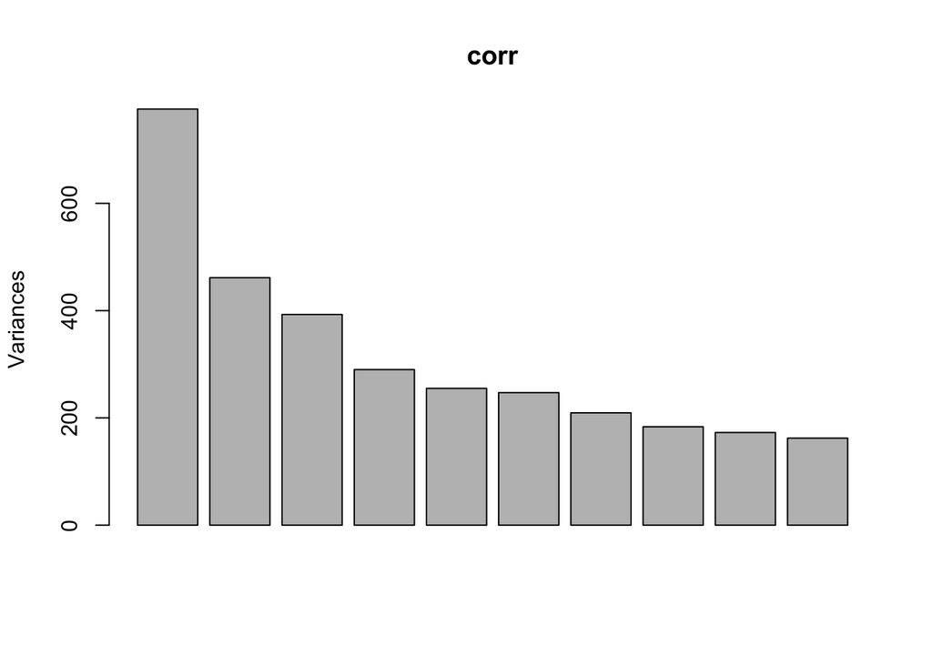

```r
screeplot(corr)
```

# Exercício 2 — Sonar (sinais; p = 60)

**Dados**: `mlbench::Sonar` (208 amostras, 60 variáveis de energia em bandas de frequência; classe M/R usada **apenas** para visualização).

1. Carregue `mlbench` e prepare `X <- scale(as.matrix(Sonar[, 1:60]))`. Guarde o vetor de classes `y <- Sonar$Class`.
2. Aplique ACP a `X`. Reporte **PVE** e **PVE acumulada**; produza o **scree plot**.
3. Faça um gráfico **CP1 vs CP2** com pontos coloridos por `y`. Comente se há **separação** entre M (mine) e R (rock).
4. Mostre um **biplot** (atenção à escala visual). Quais as **5 variáveis** com maior |loading| em CP1 e CP2?

```r
library(mlbench)
data(Sonar)
```

# Exercício 3 — Espectroscopia NIR (*yarn*; p ≈ 268 comprimentos de onda)

**Dados**: `pls::yarn`. Tem espectros NIR (muitas variáveis) e respostas químicas (ex.: `density`). Use **apenas** os **espectros** para ACP.

1. Carregue `pls` e examine `yarn`. Construa a matriz `X <- scale(yarn$NIR)` com padronização por coluna.
2. Aplique ACP a `X`. Reporte **valores próprios**, **PVE** e **PVE acumulada**. Produza os gráficos correspondentes.
3. Faça **scores plots** (CP1 vs CP2, e CP2 vs CP3). Procure padrões (e.g., batches/lotes se disponíveis).
4. Identifique **intervalos de onda** com maiores contribuições (|loadings| altos) para CP1 e CP2. Discuta possível interpretação.

```r
library(pls)
```